# Part 0: Corpus overview

The analyzed corpus holds 369 papers, published 2000–2021.

## From seed paper to corpus

The F1 corpus is built from the bibliography of the seed paper (Lund & Sindbæk 2022): its cited references, treated as a first generation of descendant works. The seed paper’s own reference list resolves to 576 works in the bibliography; the F1 corpus analyzed here holds 369, meaning 207 references were excluded.

### Selection criteria

Two exclusion criteria were applied when building the F1 set from the seed paper’s reference list:

- **Full books and edited volumes with consolidated bibliographies.** A book’s reference list is not comparable in scale or character to a journal article’s, and including it as a single node alongside articles would distort network measures, centrality in particular, that depend on reference-list size.
- **Methodological/technical reports outside the study’s interpretive scope**, judged case by case. One paper (Cannell et al. 2016, a geochemical pXRF methods chapter in an edited excavation volume) was excluded on this basis; it remains in the wider bibliography as a citation target for the papers that cite it, but was removed from the annotated F1 seed set.

No other structured record of exclusion reasons for the remaining works in the seed’s reference list currently exists; this count has not yet been individually itemized and categorized beyond these two documented criteria.

## Corpus composition

The following sections describe the corpus by publication year, entry type, authorship, venue, and language. Each has a tab for the 369-paper F1 set and a tab for the full bibliography (13,487 live entries).

### Publications by year

**F1**

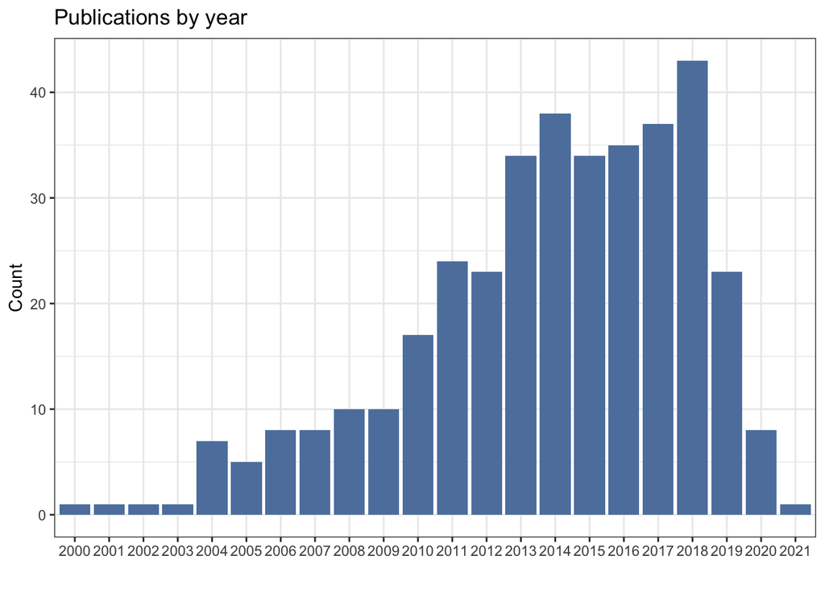

Papers published per year across the F1 corpus.

**Full corpus**

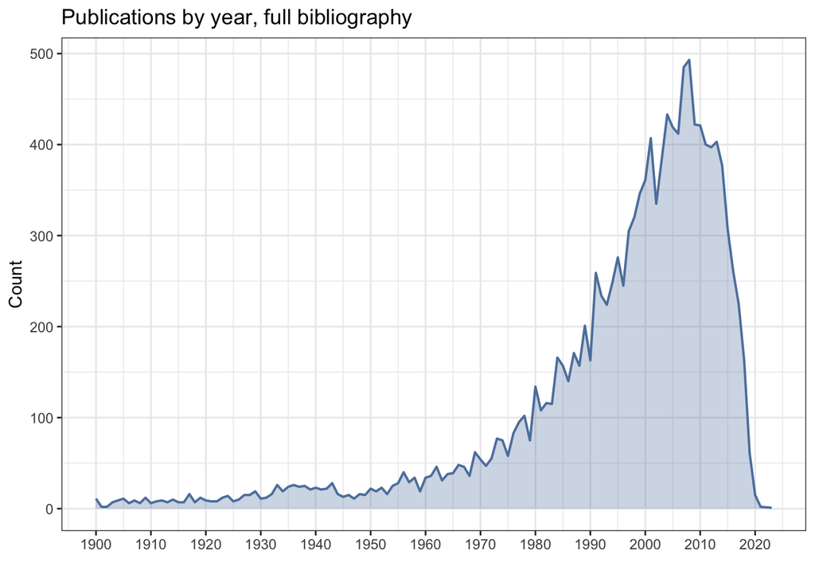

Papers published per year across the full bibliography.

The full bibliography spans 1900 to 2023, at true year-by-year resolution; 2008 is the single busiest year, with 493 entries.

### Entry types

**F1**

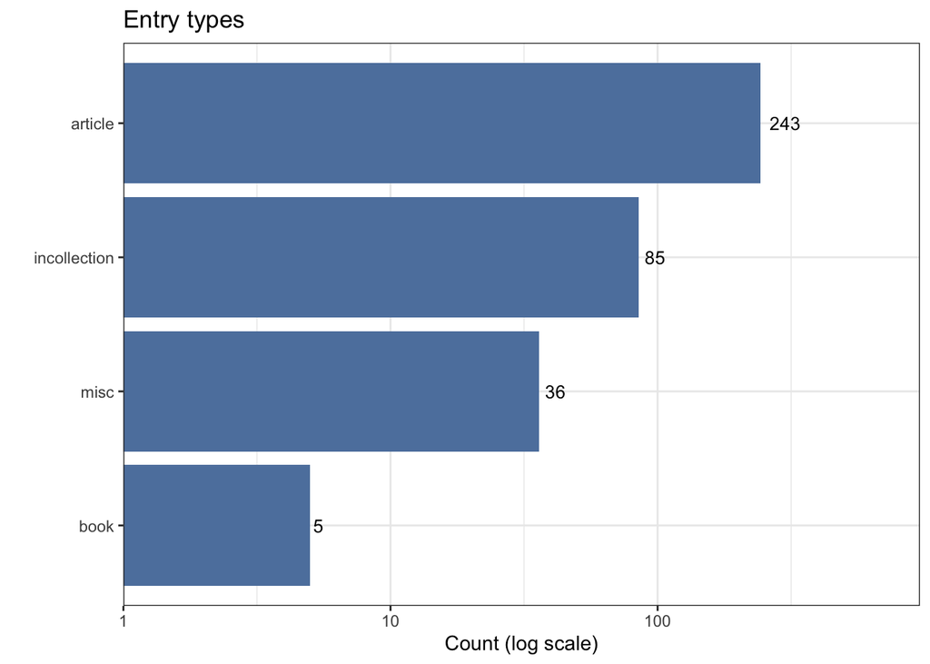

Publication type across the analyzed corpus.

4 entry types appear in the corpus. The most common, article, accounts for 243 of 369 papers (66%).

**Full corpus**

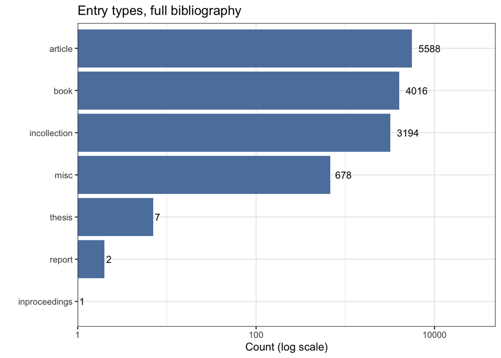

Entry type across the full bibliography.

7 entry types appear across the full bibliography. The most common, article, accounts for 5588 of 13486 entries (41%).

### Authorship

**F1**

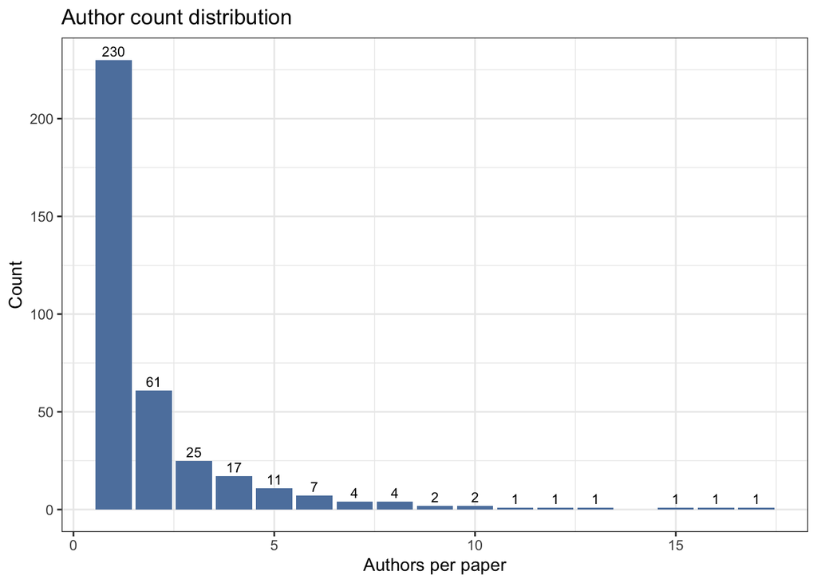

Number of authors per paper across the F1 corpus.

230 of 369 papers (62%) have a single author. One paper has 17, the largest author count in the corpus.

**Full corpus**

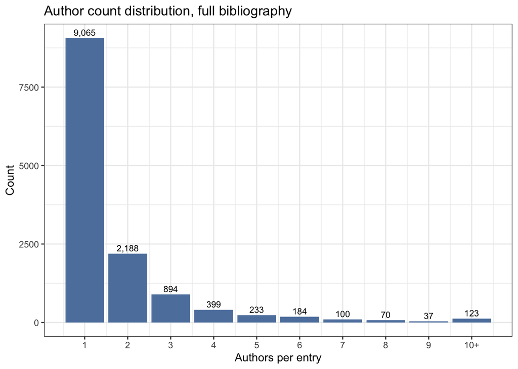

Number of authors per entry across the full bibliography, counted from the author list on each record, capped at 10 for readability, with exact counts labelled.

This full-corpus count is taken directly from the length of each record’s author list, not from the manually coded author-gender columns used for the F1 tab (those columns were only completed for the 369 F1 papers). 9065 of 13293 entries (68%) have a single listed author. The chart is capped at 10 authors for readability; 75 entries exceed that, including the largest, with 85.

### Publication venues

**F1**

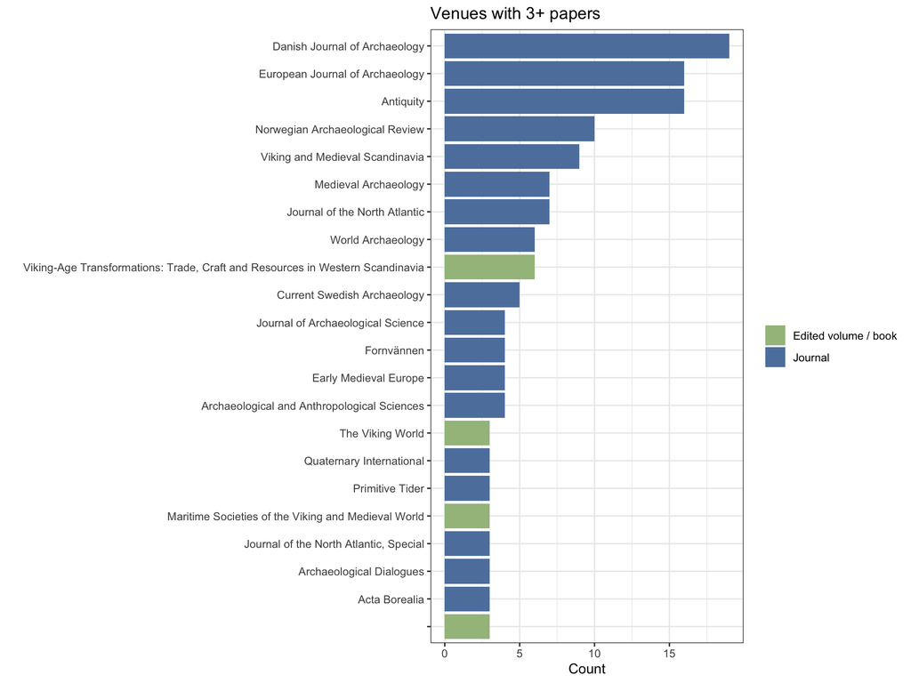

Journals and edited volumes with 3 or more F1 papers, by venue type.

363 of 369 papers are published in an identifiable journal or edited volume (publisher-only records, with neither, are excluded from this chart). The corpus draws on 229 distinct venues across both types, over half of which (192) contribute only a single paper.

**Full corpus**

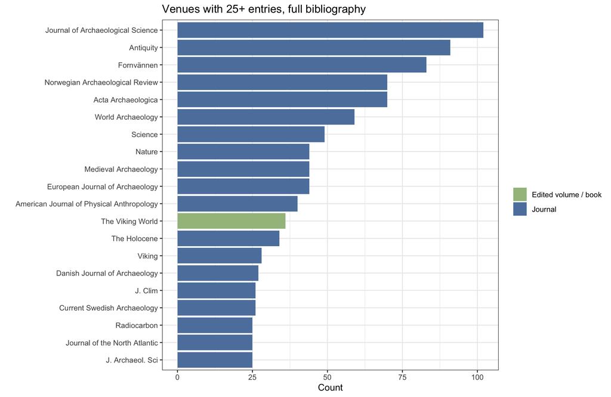

Journals and edited volumes with 25 or more entries in the full bibliography, by venue type.

9536 of 13,487 entries are published in an identifiable journal or edited volume; a further 2,163 have only a publisher recorded, typically standalone books, and are excluded from this chart since a publisher is not a comparable unit to a journal or volume title. The full bibliography draws on 5967 distinct journals and volumes, 4850 of which contribute only a single entry.

### Language

**F1**

F1 papers by detected source-PDF language, including ‘Unknown script’

| Language | N | % |
| --- | --- | --- |
| English | 324 | 91.3% |
| Swedish | 11 | 3.1% |
| Norwegian (Bokmål) | 8 | 2.3% |
| Danish | 7 | 2.0% |
| German | 3 | 0.8% |
| Russian | 1 | 0.3% |
| Ukrainian | 1 | 0.3% |

F1 papers by detected source-PDF language, excluding English.

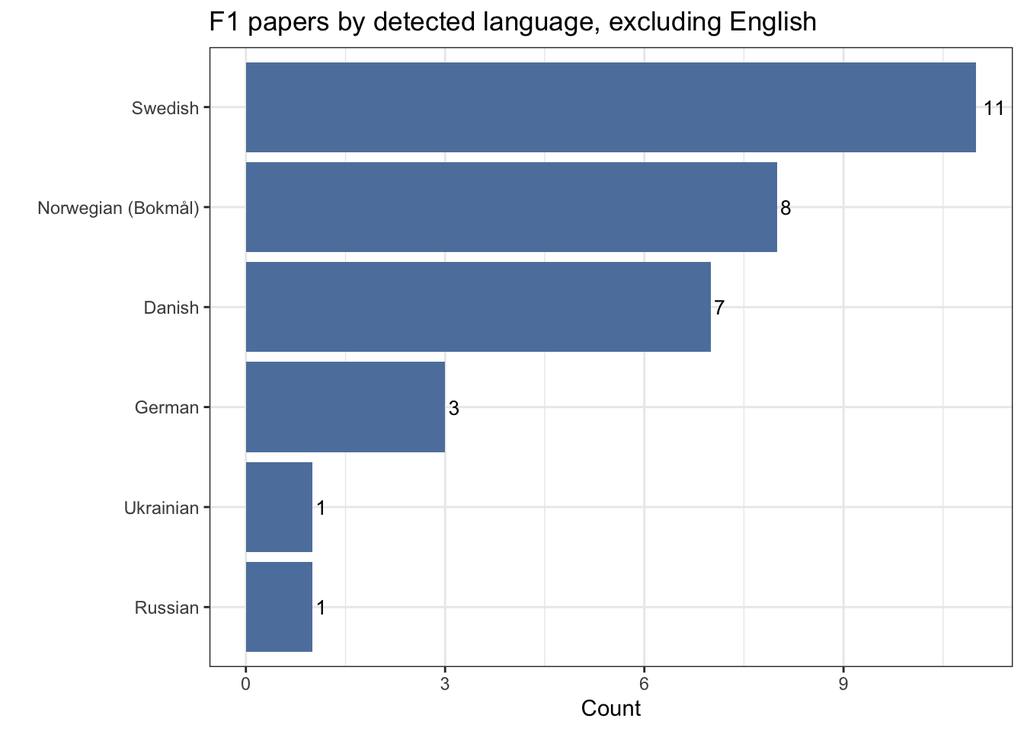

F1 papers by detected source-PDF language, excluding English.

**Full corpus**

Full bibliography by detected source-PDF language (‘Unclassified’ combines entries the detector flagged unknown and entries with no language recorded)

| Language | N | % |
| --- | --- | --- |
| English | 12591 | 93.4% |
| Swedish | 264 | 2.0% |
| Danish | 201 | 1.5% |
| Norwegian (Bokmål) | 193 | 1.4% |
| Unclassified | 116 | 0.9% |
| German | 103 | 0.8% |
| French | 17 | 0.1% |
| Russian | 1 | 0.0% |
| Ukrainian | 1 | 0.0% |

Full bibliography by detected source-PDF language, excluding English.

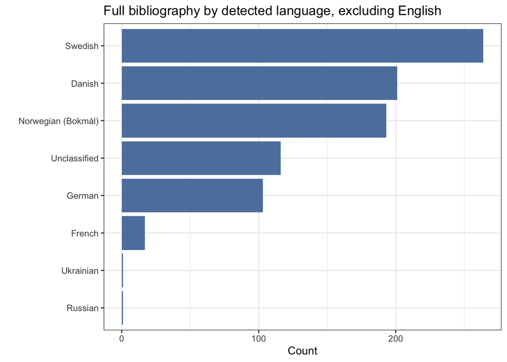

Full bibliography by detected source-PDF language, excluding English.

12591 of 13371 classified entries (94%) are English-language. 116 entries are unclassified, either flagged `unknown` by the detector or carrying no language value at all.

## Citation detection per F1 paper

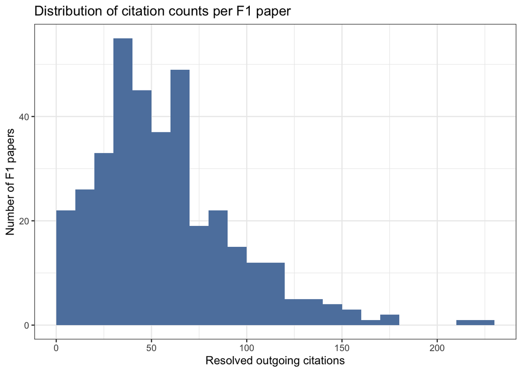

Distribution of outgoing (resolved) citation counts across the F1 corpus.

Every F1 paper has at least one resolved outgoing citation, and the citation graph as a whole forms a single connected component. This was not the case throughout corpus construction: extraction passes repeatedly left individual F1 papers disconnected, most often from a reference-list format (footnote-embedded citations, a shared reference section for an edited volume, non-Latin or corrupted encoding) the primary extraction method did not handle, or from the same work being independently extracted twice under two citekeys. Each case was resolved against the original source PDF or documented as a genuine structural exception.

## From detection to resolved bibliography

The citation graph is built in two stages: automated detection of candidate citations per paper, then manual correction and deduplication across the whole bibliography.

Raw citation detections by method, before merging duplicate detections of the same citation

| Detection method | Raw detections |
| --- | --- |
| Structured reference list (GROBID) | 24560 |
| Inline citation markers | 17754 |
| LLM body-text scan | 11487 |
| Text-pattern matching | 10538 |
| LLM bibliography reparse | 1671 |
| LLM footnote scan | 673 |

Once detected, citations are carried into a single shared bibliography, where the same underlying work can be independently detected from multiple citing papers and needs consolidating into one record. This consolidation, along with other manual corrections, is tracked in a running corrections file (`corrections.yaml`) rather than as edits to the raw pipeline output.

Manual, individually-reasoned correction actions applied to the bibliography (corrections.yaml)

| Action | Count |
| --- | --- |
| set (field corrections: author, year, title, citer lists, etc.) | 17528 |
| delete (fabricated or unresolvable ghost entries removed) | 1770 |
| create (missing entries added from manually verified source data) | 960 |
| merge (duplicate entries combined) | 396 |
| reject (candidate merges/matches checked and confirmed distinct) | 80 |
| split (single entries separated into multiple genuine works) | 19 |

Two bulk, mechanical field backfills are tracked in the same file but excluded from the table above: a `language` value was set on 12,807 entries and a `detection` value on 12,804 entries, both copied wholesale from the pipeline’s own processing cache rather than individually reasoned. Combined they account for more `set` actions than every other correction in the file put together, so are reported separately to avoid making the file’s manual-correction volume look larger than it is.

As of this writing the file holds 20753 individually-reasoned correction actions, plus the 25,611 bulk field backfills noted above. The great majority of `delete` actions removed “ghost” entries: records with no title and no raw citation text, produced when the extraction pipeline generated a placeholder entry it was never able to resolve to a real source. `merge` actions consolidated cases where the same underlying work had been independently created under two or more citekeys, most commonly because one version came from an automated reference-list extraction with no linked PDF and a second, fuller version was later created when the paper’s own PDF was located and processed directly, or because the same source was independently extracted from two different citing papers’ reference lists, the cross-paper duplication this section exists to resolve. `set` actions in the table above cover routine field-level corrections: fixing fabricated or garbled author names, correcting mis-parsed years and titles, and adding real citation relationships (`cited_by` entries) that automated detection missed or failed to resolve on the first pass.

One deletion in this file was subsequently confirmed incorrect and reversed: a genuine F1 paper had been marked fabricated across multiple earlier review passes despite being a real, verifiable source, and was restored with corrected metadata once checked directly against its source PDF. This is noted here as a reminder that `delete` corrections, like any other, should be treated as provisional until checked against a primary source rather than as settled fact on the strength of a confident-sounding note.